# Random intercept model met 2 niveaus

Op deze pagina vind je een demonstratie van een statistische techniek aan de hand van een voorbeeld.

Meer informatie over hoe je deze pagina kan gebruiken vind je in deze handleiding.

De analyse gebeurt met behulp van R en RStudio. Een inleiding tot deze software vind je [hier](https://ufora.ugent.be/d2l/le/discovery/view/course/386505).

Het voorbeeld op deze pagina is afkomstig van een studie van Bogaert, Merchie, Van Ammel & Van Keer (2025). Er zijn enkele wijzigingen aangebracht om didactische redenen. De studie is ook uitgebreider dan wat op deze pagina wordt gedemonstreerd.

# 1 Het voorbeeld op deze pagina

Bogaert et al. (2025) onderzoeken de impact van een interventie op verschillende maten van leesvaardigheid van leerlingen. Hun studie is gemotiveerd door de vaststelling dat leesvaardigheden vaak onvoldoende ontwikkeld zijn bij leerlingen in de latere jaren van het basisonderwijs. Bovendien zijn er onbeantwoorde vragen over welke lesmethoden effectief zouden kunnen zijn bij het verbeteren van de leesvaardigheden van leerlingen. Studies die uitzoeken of interventies op klasniveau zouden kunnen werken zijn bijzonder schaars. De auteurs hadden de intentie om die lacune in de bestaande wetenschappelijke literatuur te verhelpen.

De interventie in de studie van Bogaert et al. (2025) houdt in dat leerlingen uit het basisonderwijs gedurende tien weken een lessenpakket volgen dat specifiek gericht is op het verbeteren van verschillende uitkomsten:

- de mate waarin leerlingen een tekst begrijpen (“reading comprehension”)
- het gebruik van verschillende strategieën om een tekst te begrijpen (“reading strategy use”)
- verschillende vormen van leesmotivatie (“reading motivation”)

In de demonstratie op deze pagina focussen we enkel op de eerste van die uitkomstvariabelen: het begrijpend lezen.

Naast de leerlingen bij wie de interventie plaatsvond, bestudeerden Bogaert et al. (2025) ook leerlingen bij wie geen aanpassingen aan het lessenpakket zijn gebeurd. Zij hebben lessen gevolgd zoals gewoonlijk. In de variabele `Conditie` wordt geregistreerd of een leerling tot de experimentele groep (met interventie) of tot de controlegroep (zonder interventie) behoort.[^1]

Alle leerlingen legden twee testen af die peilen naar capaciteiten met betrekking tot begrijpend lezen. De eerste test vond plaats voor de interventie (variabele `BL_pretest`), de tweede erna (variabele `BL_posttest`).[^2]

Een belangrijke vraag die de auteurs zich stelden was of de interventie (`Conditie`) gemiddeld genomen een effect heeft op de testscore (`BL_posttest`), rekening houdend met eventuele andere predictoren.

Op het eerste zicht lijkt dit een vraag die kan worden beantwoord aan de hand van een klassiek [lineair regressiemodel met een categorische predictor](https://statlas.ugent.be/technieken/Lineaire%20regressie/meervoudige-lineaire-regressie--categorisch-.html) (`Conditie`). In de volgende sectie zetten we kort uiteen waarom dat niet het geval is en hoe het beter kan.

# 2 Waarom een multilevel model met random intercept?

Om te begrijpen waarom klassieke lineaire regressie hier niet geschikt is moeten we focussen op de manier waarop de data zijn verzameld. In Bogaert et al. (2025) werden willekeurig scholen geselecteerd en vervolgens klassen in die scholen en daarna werden leerlingen binnen die klassen getest. De data zijn met andere woorden hiërarchisch gestructureerd, in dit geval met drie niveaus: scholen, klassen en individuele leerlingen. Voor deze inleidende demonstratie zullen we de context wat vereenvoudigen naar een **structuur met twee niveaus**: we gaan ervan uit dat willekeurige klassen werden geselecteerd en dat vervolgens leerlingen binnen die klassen werden getest.

Als onderzoeker zou je kunnen vermoeden dat de uitkomst (testscores `BL_posttest`) geclusterd is per klas. **Clustering** betekent dat de scores binnen klassen meer op elkaar lijken dan wanneer je de scores over alle klassen heen zou beschouwen. Op basis van de klas waartoe een leerling behoort zou je dus al iets kunnen zeggen over de score die die leerling behaalt op de test (`BL_posttest`). Er zou met andere woorden een “klaseffect” zijn op de testscore.[^3]

De mogelijke aanwezigheid van een klaseffect kan relevant zijn bij het beantwoorden van de onderzoeksvraag. De interesse van de onderzoekers gaat uit naar het effect van `Conditie` op `BL_posttest`. Als we een zuiver beeld willen van dit effect, dan moeten we **controleren voor het klaseffect**. De doelstelling is dezelfde als die van statistische controle bij lineaire regressie. Er zijn echter goede redenen om het niet op die klassieke manier aan te pakken.

De belangrijkste reden is dat de niveaus van de categorische variabele `Klas` op een willekeurige wijze aanwezig zijn in de data. Dat is een direct gevolg van de manier waarop de steekproef tot stand is gekomen: de klassen zijn willekeurig getrokken uit alle mogelijke klassen. De waarden van `Klas` die in een steekproef voorkomen zijn een willekeurige greep uit alle mogelijke waarden. In jouw steekproef zal misschien “het 6e studiejaar van Stedelijke Basisschool De Brug in Roeselare” wel aanwezig zijn en “het 5e studiejaar van Vrije Basisschool De Klimop in Sint-Gillis-Waas” niet. In een andere steekproef zou het omgekeerd kunnen zijn.

Dat is natuurlijk heel verschillend van wat je gewoon bent bij categorische variabelen. Bijvoorbeeld, bij een variabele als `Opleidingsniveau` met 4 niveaus zal je niet een willekeurige trekking van die niveaus nemen, om vervolgens binnen elk getrokken niveau willekeurig individuen te trekken.

Doordat de niveaus van `Klas` willekeurig getrokken zijn, zijn ook de effecten die geassocieerd zijn met die niveaus willekeurig. Het zijn met andere woorden **random effecten**. Als je in een dergelijke context een klassiek lineair regressiemodel zou fitten, dan kan je je conclusies maar in beperkte mate generaliseren. Je conclusies gelden voor alle leerlingen *binnen de specifieke getrokken klassen*.[^4] Een multilevel model daarentegen laat toe om je conclusies wél te generaliseren naar alle leerlingen *in alle klassen*.

Een bijkomende reden om voor een multilevel model te kiezen is efficiënt gebruik van de data. De dataset kan heel veel klassen bevatten. Daardoor zou een lineair regressiemodel heel veel parameters bevatten waar we niet echt in geïnteresseerd zijn, maar die wel moeten worden geschat. Bijvoorbeeld, het effect van in klas “het 6e studiejaar van Stedelijke Basisschool De Brug in Roeselare” te zitten in vergelijking met het referentieniveau. Analoog zou je het effect moeten schatten voor alle klassen in je dataset. Dat zouden we moeten doen om de statistische controle te kunnen uitvoeren, niet omdat al die effecten ons inhoudelijk interesseren. Dat is geen efficiënt gebruik van de data, die beter zouden worden gespendeerd aan het verbeteren van de power van de toets waar we wel in geïnteresseerd zijn, in dit geval de toets van het effect van `Conditie`.

In deze demonstratie komen enkel random intercepten aan bod. Daarbij verschilt dus het niveau van de uitkomst `BL_posttest` (random) per klas, ongeacht de `Conditie`. Merk op dat er ook “random slope” modellen bestaan. Daarbij kan niet alleen het intercept, maar ook de sterkte van het verband (en dus de helling van de rechte) variëren per klas. Dergelijke modellen worden op deze pagina niet gedemonstreerd. Een goede maar erg beknopte Engelstalige demonstratie vind je [hier](https://www.rensvandeschoot.com/tutorials/lme4/).

## Terminologie

Multilevel modellen staan ook bekend als (linear) mixed models, mixed effects models en hiërarchische lineaire modellen.

# 3 Data & packages

Voor een multilevel analyse in R gebruikt men meestal twee packages: `lme4` en `lmerTest`. Indien deze nog niet geïnstalleerd zijn op je computer dan moet je dit eerst eenmalig doen.

```r
install.packages(c('lme4', 'lmerTest'))
```

Als de packages geïnstalleerd zijn laad je ze voor gebruik. Het is in dit geval belangrijk dat je de volgorde van het laden respecteert: eerst `lme4`, dan `lmerTest`.[^5]

```r
library(lme4)
library(lmerTest)
```

Verderop zullen we voor enkele heel specifieke doeleinden nog een aantal packages gebruiken. We verduidelijken dit wanneer het relevant is.

De data voor deze demonstratie komen van Bogaert et al. (2025). Je kan ze inladen met de volgende code. De namen van de variabelen zijn vertaald en licht aangepast voor de duidelijkheid.

```r
lezen <- read.csv('https://statlas.ugent.be/datasets/mlm.csv')
```

Het is een goed idee om categorische variabelen meteen om te zetten naar het datatype `factor`. Indien gewenst kan je ook `labels` toevoegen. Uiteraard is het belangrijk om hier geen fouten te maken door de volgorde om te keren.

```r
lezen$School <- factor(lezen$School)
lezen$Klas <- factor(lezen$Klas)
lezen$Conditie <- factor(lezen$Conditie, labels=c('Controle', 'Experimenteel'))
lezen$Niveau <- factor(lezen$Niveau, labels=c('Goed', 'Middelmatig', 'Zwak'))
lezen$Dyslexie <- factor(lezen$Dyslexie, labels=c('Nee', 'Ja'))
```

# 4 Is de uitkomst geclusterd?

Het kan interessant zijn om te weten in welke mate de uitkomstvariabele geclusterd is op een hoger niveau.

In Bogaert et al. (2025) ligt de focus op de uitkomstvariabele `BL_posttest`. Deze variabele is gemeten op het niveau van de individuele leerlingen (niveau 1).

Leerlingen maken deel uit van klassen (niveau 2). Als onderzoeker kan je vermoeden dat klassen van elkaar verschillen in termen van scores op de posttest. Anders gezegd, de posttest-scores binnen klassen lijken mogelijk wat meer op elkaar dan wanneer je alle leerlingen over alle klassen heen zou beschouwen.

We vragen ons af of dat vermoeden klopt. Om dat te beantwoorden bouwen we een nulmodel of een intercept-only model. Dat dient enkel om de variantie in `BL_posttest` op te splitsen in variantie op niveau 1 en variantie op niveau 2. De functie `lmer()` laat toe om een nulmodel te bouwen. Bij het argument `formula` specifiëren we een model zonder echte predictoren. Door `(1|Klas)` te schrijven laten we wel een afzonderlijk intercept toe per klas. Met `summary()` vragen we de belangrijkste informatie over dit model op.

```r
model0 <- lmer(formula = BL_posttest ~ (1|Klas), data=lezen)
summary(model0)
```

```
Linear mixed model fit by REML. t-tests use Satterthwaite's method ['lmerModLmerTest']
Formula: BL_posttest ~ (1 | Klas)
   Data: lezen

REML criterion at convergence: 1579.3

Scaled residuals:
    Min      1Q  Median      3Q     Max
-2.5693 -0.6433 -0.1237  0.4940  7.5250

Random effects:
 Groups   Name        Variance Std.Dev.
 Klas     (Intercept) 0.1928   0.4391
 Residual             1.6473   1.2835
Number of obs: 464, groups:  Klas, 27

Fixed effects:
            Estimate Std. Error       df t value Pr(>|t|)
(Intercept)  0.02125    0.10464 26.50000   0.203    0.841
```

In de output van `summary(model0)`, onder `Random effects` vinden we de opgesplitste variantie terug. De variantie op niveau 1 (naast `Residual`) is duidelijk het grootst, maar er is toch ook variantie op het niveau van de klassen.

Een visualisatie van de data opgesplitst per klas kan helpen om een idee te krijgen van de verhouding tussen deze varianties.

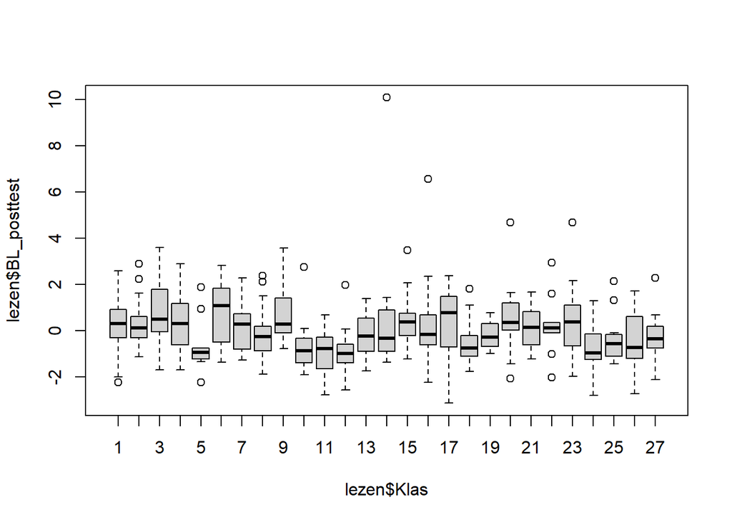

```r
boxplot(lezen$BL_posttest ~ lezen$Klas)
```

Elke boxplot stelt de data in een van de 27 klassen voor. We komen tot een gelijkaardige conclusie: er lijkt toch variantie te bestaan *tussen* de klassen, met andere woorden variantie op niveau 2.

Om de verhouding tussen de varianties op verschillende niveaus te kwantificeren kunnen we de intraclass correlatie (ICC) berekenen.

## 4.1 Intraclass correlatie (ICC)

De intraclass correlatie (ICC) drukt uit hoe sterk de clustering op niveau 2 is. De ICC geeft de proportie weer van de variantie op niveau 2 ($\sigma^2_{klas}$) ten opzichte van de totale variantie ($\sigma^2_{klas} + \sigma^2_{res}$). De ICC kan waarden aannemen van 0 tot 1.[^6] De nodige gegevens om de ICC te berekenen zijn te vinden in de output van `summary(model0)`.

$$ICC =
\frac{\sigma^2_{klas}}{\sigma^2_{klas} + \sigma^2_{res}}$$

In onze steekproef wordt dat

$$\frac{0.1928}{0.1928 + 1.6473} =
0.1049823 \approx 0.105$$

In dit geval is de ICC ongeveer gelijk aan $0.105$ of $10.5\%$.

Het package `performance` biedt een functie `icc` aan die de berekening voor ons kan maken. Installeer het package met `install.packages()` indien je dat nog niet hebt gedaan en laad het met `library()`.

```r
install.packages('performance')
library(performance)

icc(model0)
```

```
# Intraclass Correlation Coefficient

    Adjusted ICC: 0.105
  Unadjusted ICC: 0.105
```

Als we een nulmodel aan de functie `icc()` geven zal er geen verschil zijn tussen de `Adjusted` en de `Unadjusted` varianten. Met het commando `?icc` kan je de helppagina opvragen waar je een uitleg vindt over het verschil tussen beide.

## 4.2 Random intercepten visualiseren

Een makkelijke manier om de random intercepten te visualiseren is met de functie `dotplot()` van het package `lattice`. Met de functie `ranef()` kan je de random intercepten van een model (hier `model0`) opvragen. Die geef je aan de functie `dotplot()`. Je ziet in de output voor elke klas het random intercept.

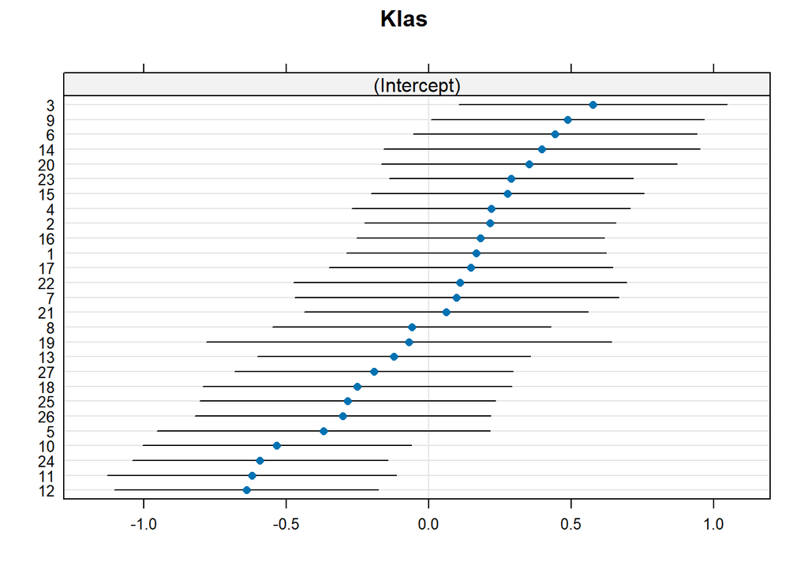

```r
library(lattice)

dotplot(ranef(model0))
```

Multilevel modellen maken de assumptie dat random intercepten een normale verdeling volgen. Met de functies `qqnorm()` en `qqline()` is het mogelijk om na te gaan of aan deze assumptie is voldaan. Hieronder zie je dit toegepast voor het nulmodel `model0` en voor clustervariabele `Klas` (de enige clustervariabele in dit voorbeeld).

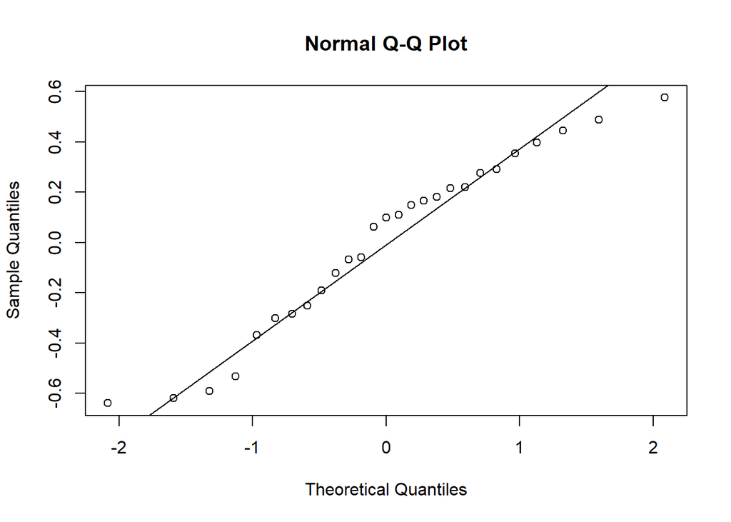

```r
qqnorm(ranef(model0)$Klas[,1])
qqline(ranef(model0)$Klas[,1])
```

De punten wijken niet heel veel af van de rechte. Bijgevolg hebben we geen overtuigende reden om te denken dat de assumptie van normaliteit geschonden is.

# 5 Effecten schatten en toetsen

Bogaert et al. (2025) zijn geïnteresseerd in het effect van een interventie (categorische variabele `Conditie`) op de testscore van leerlingen na de interventie `BL_posttest`. Een bijkomende controlevariabele in hun model is de score van leerlingen op de test vóór de interventie (continue variabele `BL_pretest`).

Algemeen gesteld kan je gelijk welke combinatie van categorische en continue predictoren - ook met interactie-effecten - in een multilevel model opnemen, net als bij klassieke lineaire regressie.

We analyseren hieronder eerst het effect van `BL_pretest` op `BL_posttest` en daarna voegen we de predictor `Conditie` toe aan het model. Dit laat ons toe om zowel de analyse van een continue predictor als van een categorische predictor te demonstreren. Daarna tonen we hoe je een interactie-effect kan toevoegen.

## 5.1 Continue predictor `BL_pretest`

Eerst bouwen we het model met enkel de pretestscores `BL_pretest` als predictor, naast het random intercept per `Klas`. Het effect van deze pretestscores is wetenschappelijk niet bijzonder interessant. Het is ook niet waarin Bogaert et al. (2025) direct geïnteresseerd zijn. We staan er enkel bij stil om te demonstreren hoe je het effect van een continue predictor kan toetsen.

### Specificatie in R

De specificatie van het model met predictor `BL_pretest` is gelijkaardig aan de specificatie van het nulmodel. Het enige verschil is de toevoeging van `BL_pretest` bij het argument `formula`.

```r
model.prtst <- lmer(formula = BL_posttest ~ BL_pretest + (1|Klas), data=lezen)
```

In een diagram ziet dit model er zo uit (klik op de afbeelding om te vergroten):

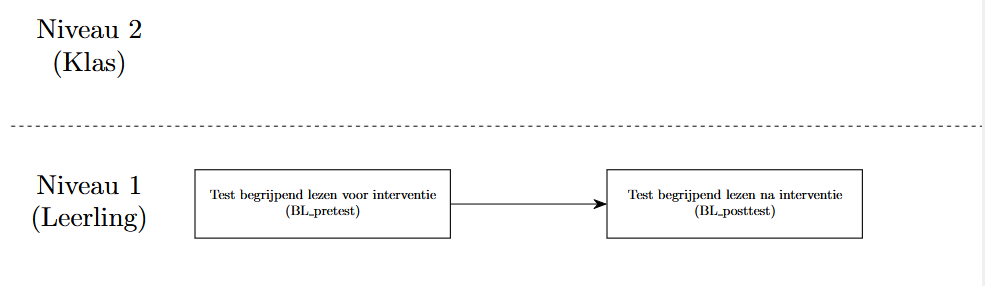

### Parameters schatten

De belangrijkste informatie over de parameterschattingen bekomen we met de functie `summary()`.

```r
summary(model.prtst)
```

```
Linear mixed model fit by REML. t-tests use Satterthwaite's method ['lmerModLmerTest']
Formula: BL_posttest ~ BL_pretest + (1 | Klas)
   Data: lezen

REML criterion at convergence: 1442.6

Scaled residuals:
    Min      1Q  Median      3Q     Max
-2.3733 -0.6071 -0.0867  0.4709  7.7703

Random effects:
 Groups   Name        Variance Std.Dev.
 Klas     (Intercept) 0.02737  0.1654
 Residual             1.34285  1.1588
Number of obs: 456, groups:  Klas, 27

Fixed effects:
             Estimate Std. Error        df t value Pr(>|t|)
(Intercept)   0.02334    0.06347  22.12260   0.368    0.717
BL_pretest    0.51553    0.04245 402.82000  12.144   <2e-16 ***
---
Signif. codes:  0 '***' 0.001 '**' 0.01 '*' 0.05 '.' 0.1 ' ' 1

Correlation of Fixed Effects:
           (Intr)
BL_pretest -0.006
```

In deze output is het de coëfficiënt onder `Fixed effects` bij `BL_pretest` die ons het meest interesseert.

We zien daar 0.51553 staan. Dat is de puntschatting voor het effect van `BL_pretest` op `BL_posttest`, controlerend voor het klaseffect. Hier schatten we dat de score op `BL_posttest`, gemiddeld over alle leerlingen van alle klassen heen, 0.51553 punten hoger ligt wanneer de score op `BL_pretest` met 1 eenheid toeneemt, controlerend voor het klaseffect.

Het is een goed idee om naast puntschattingen ook betrouwbaarheidsintervallen te rapporteren. Dat kan met de functie `confint()`. Standaard krijg je een 95%-betrouwbaarheidsinterval.

```r
confint(model.prtst)
```

```
Computing profile confidence intervals ...
```

```
                 2.5 %    97.5 %
.sig01       0.0000000 0.3306104
.sigma       1.0843316 1.2399720
(Intercept) -0.1033102 0.1497472
BL_pretest   0.4301067 0.6052039
```

Terzijde, de output van `summary(model.prtst)` bevat ook een intercept bij de `Fixed effects`. Het gaat hier over het intercept over alle klassen heen. Voor een leerling met `BL_pretest` gelijk aan 0 verwachten we een score van `0.02334` op de `BL_posttest`.

### Toetsen

De relevante nulhypothese en alternatieve hypothese zijn de volgende.

- De nulhypothese stelt dat de populatieparameter $\beta_{pretest}$ gelijk is aan 0. In dat geval is er geen effect van `BL_pretest`.
- De alternatieve hypothese stelt dat de populatieparameter $\beta_{pretest}$ verschillend is van 0. In dat geval is er wel een effect van `BL_pretest`.

Op dezelfde rij in de output van `summary()` (zie hierboven) vinden we ook de nodige informatie om het effect van `BL_pretest` te toetsen. Deze werkwijze zal echter niet in elke situatie werken. Met name bij een categorische predictor en bij modellen met een interactie-effect zal je met `summary()` vaak niet de gewenste toets kunnen uitvoeren. Daarom demonstreren we hier meteen een werkwijze die wel algemeen toepasbaar is.

Die werkwijze bestaan erin dat we:

1. overgaan tot effectcodering van alle categorische predictoren
2. een modelvergelijking uitvoeren met de functie `Anova()` uit het package `car`
3. het argument `type=3` meegeven aan `Anova()`

Meer uitleg over effectcodering en type III toetsen kan je vinden [in deze syllabus](https://statlas.ugent.be/cursussen/MetPsy_cursus20-21_lineaire_regr.pdf#page=64) vanaf sectie 5.3. De uitleg gebeurt in de context van klassieke lineaire regressie (dus niet multilevel modellen) maar de principes zijn identiek.

In `model.prtst` zijn geen categorische predictoren, dus die stap kunnen we overslaan. Het argument `type=3` speelt enkel een rol wanneer er een interactie-effect in het model zit, maar voor de volledigheid voegen we het hier toch toe.

```r
library(car)
Anova(model.prtst, type=3)       # Let op de hoofdletter "A"
```

```
Analysis of Deviance Table (Type III Wald chisquare tests)

Response: BL_posttest
               Chisq Df Pr(>Chisq)
(Intercept)   0.1352  1     0.7131
BL_pretest  147.4707  1     <2e-16 ***
---
Signif. codes:  0 '***' 0.001 '**' 0.01 '*' 0.05 '.' 0.1 ' ' 1
```

Aangezien de p-waarde ongeveer gelijk is aan 0 kunnen we de nulhypothese verwerpen op het 5% significantieniveau.

Voor een vollediger voorbeeld van deze werkwijze, zie verderop.

### Visualisatie

Het model dat we zonet hebben gefit met `lmer()` kan visueel worden weergegeven als parallelle rechten door een puntenwolk.[^7] Er is 1 rechte per klas. De plot is wat ingezoomd om de verschillende rechten iets duidelijker weer te geven.

- Elke klas heeft een eigen rechte omdat elke klas een eigen random intercept heeft.
- De rechten zijn parallel omdat het effect van `BL_pretest` in elke klas gelijk is. Het is met andere woorden louter een fixed effect in dit model.[^8]

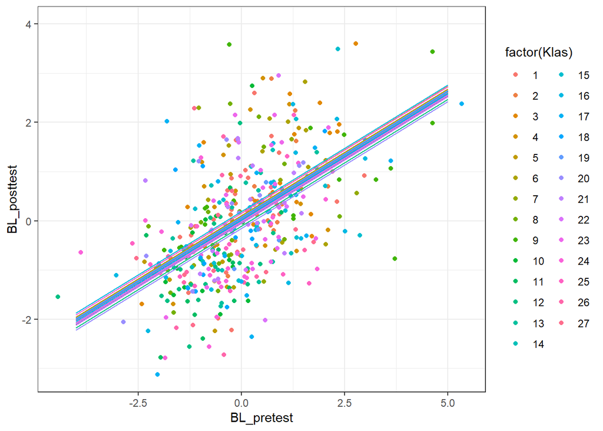

Bovenstaande visualisatie is omslachtig om te maken en leggen we daarom hier niet verder uit.

Een visualisatie enkel van het fixed effect van `BL_pretest` is makkelijker, dankzij het package `effects`. Je geeft de predictor en het model aan de functie `effect()` en geeft dit op zijn beurt aan de functie `plot()`.

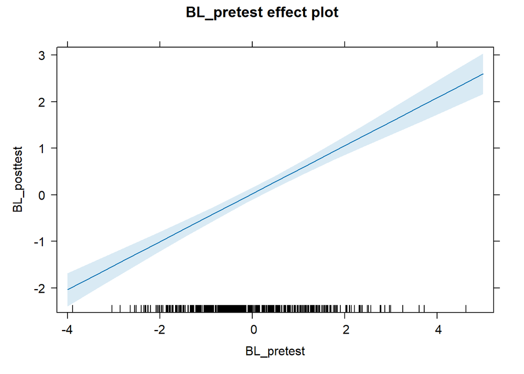

```r
install.packages('effects') # eenmalig
library(effects)

plot(effect('BL_pretest', model.prtst))
```

## 5.2 Categorische predictor `Conditie`

De centrale focus in Bogaert et al. (2025) was een hypothese over het effect van de predictor `Conditie` op `BL_posttest`.

### Specificatie in R

We willen een model met de predictor `Conditie`, samen met `BL_pretest` en het random intercept. Dat kan heel eenvoudig door een term `Conditie` toe te voegen aan het argument `formula`.

```r
model.cndt <- lmer(formula = BL_posttest ~ BL_pretest + Conditie + (1|Klas), data=lezen)
```

In een diagram ziet dit model er zo uit (klik op de afbeelding om te vergroten):

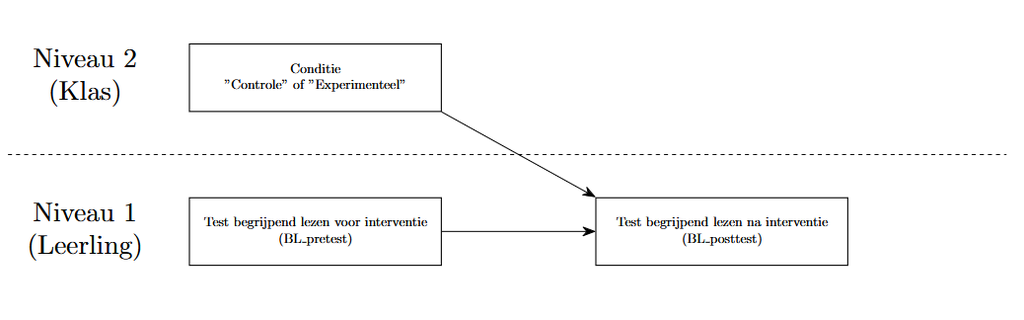

Merk op dat de predictor `Conditie` in het diagram gesitueerd is op niveau 2. De interventie zelf bestaat uit een lessenpakket dat klassikaal wordt gebracht aan de leerlingen. Daardoor behoren alle leerlingen van dezelfde klas onvermijdelijk tot dezelfde conditie. De predictor `Conditie` is dus eerder een variabele op klasniveau dan op het individuele niveau. Dat hoeft geen probleem te zijn. Het is perfect mogelijk om predictoren van verschillende niveaus te combineren in een multilevel model.

### Parameters schatten

We vragen de belangrijkste informatie met betrekking tot de parameterschattingen op met de functie `summary()`. De predictor `Conditie` is een binaire categorische variabele. Daardoor is er slechts 1 parameter die voor het effect van `Conditie` codeert. De schatting van die ene parameter is te vinden onder `Fixed effects` bij `ConditieExperimenteel`.

```r
summary(model.cndt)
```

```
Linear mixed model fit by REML. t-tests use Satterthwaite's method ['lmerModLmerTest']
Formula: BL_posttest ~ BL_pretest + Conditie + (1 | Klas)
   Data: lezen

REML criterion at convergence: 1444.8

Scaled residuals:
    Min      1Q  Median      3Q     Max
-2.3758 -0.6082 -0.0870  0.4655  7.7631

Random effects:
 Groups   Name        Variance Std.Dev.
 Klas     (Intercept) 0.03204  0.179
 Residual             1.34264  1.159
Number of obs: 456, groups:  Klas, 27

Fixed effects:
                       Estimate Std. Error        df t value Pr(>|t|)
(Intercept)             0.02935    0.09190  20.81138   0.319    0.753
BL_pretest              0.51366    0.04258 404.54484  12.065   <2e-16 ***
ConditieExperimenteel  -0.01206    0.12980  21.32136  -0.093    0.927
---
Signif. codes:  0 '***' 0.001 '**' 0.01 '*' 0.05 '.' 0.1 ' ' 1

Correlation of Fixed Effects:
            (Intr) BL_prt
BL_pretest   0.009
CndtExprmnt -0.708 -0.018
```

Hier wordt geschat dat het gemiddelde effect, over alle leerlingen van alle klassen heen, van in de experimentele groep te zitten in vergelijking met de controlegroep (= het referentieniveau), controlerend voor de andere predictoren, gelijk is aan -0.01206.

Een leerling in de experimentele conditie heeft een score op `BL_posttest` die, gemiddeld over alle leerlingen van alle klassen heen, 0.01206 punten lager ligt dan een leerling in de controleconditie, controlerend voor het klaseffect en voor `BL_pretest`.

Het is een goed idee om naast puntschattingen ook betrouwbaarheidsintervallen voor de parameters te rapporteren. Dat kan met de functie `confint()`. Standaard krijg je een 95%-betrouwbaarheidsinterval.

```r
confint(model.cndt)
```

```
Computing profile confidence intervals ...
```

```
                           2.5 %    97.5 %
.sig01                 0.0000000 0.3302957
.sigma                 1.0843798 1.2400675
(Intercept)           -0.1506928 0.2077439
BL_pretest             0.4302338 0.6055554
ConditieExperimenteel -0.2637086 0.2424676
```

### Toetsen

De relevante nulhypothese en alternatieve hypothese bij het toetsen van het effect van een categorische predictor zijn de volgende.

- De nulhypothese stelt dat alle populatieparameters (“bèta’s”) die coderen voor de categorische variabele `Conditie` gelijk zijn aan 0. Dat betekent dat er geen effect is van `Conditie`.
- De alternatieve hypothese stelt dat minstens een van deze populatieparameters verschillend is van 0. Als dat klopt is er wel een effect van `Conditie`.

In dit specifieke geval zouden we de toets kunnen uitvoeren op basis van de output van `summary()`.[^9] Omdat dit in veel situaties niet mogelijk is, zullen we hier focussen op een algemeen toepasbare werkwijze:

1. overgaan tot effectcodering van alle categorische predictoren
2. een modelvergelijking uitvoeren met de functie `Anova()` uit het package `car`
3. het argument `type=3` meegeven aan `Anova()`

Meer uitleg over effectcodering en type III toetsen kan je vinden [in deze syllabus](https://statlas.ugent.be/cursussen/MetPsy_cursus20-21_lineaire_regr.pdf#page=64) vanaf sectie 5.3. De uitleg gebeurt in de context van klassieke lineaire regressie (dus niet multilevel modellen) maar de principes zijn identiek.

Voor de eerste stap moeten we het model opnieuw fitten, waarbij we een extra argument `contrasts` meegeven.

```r
model.cndt.effect <- lmer(formula = BL_posttest ~ BL_pretest + Conditie + (1|Klas),
                          contrasts=list(Conditie=contr.sum),
                          data=lezen)
```

```r
library(car)
Anova(model.cndt.effect, type=3)
```

```
Analysis of Deviance Table (Type III Wald chisquare tests)

Response: BL_posttest
               Chisq Df Pr(>Chisq)
(Intercept)   0.1291  1     0.7194
BL_pretest  145.5551  1     <2e-16 ***
Conditie      0.0086  1     0.9260
---
Signif. codes:  0 '***' 0.001 '**' 0.01 '*' 0.05 '.' 0.1 ' ' 1
```

Het argument `type=3` speelt enkel een rol wanneer er een interactie-effect in het model aanwezig is, maar voor de volledigheid voegen we het hier toch toe.

De p-waarde is ongeveer gelijk aan 0.926. Dit is groter dan 0.05 waardoor we de nulhypothese niet kunnen verwerpen op het 5% significantieniveau.

### Visualisatie

Het (fixed) effect van `Conditie` kan eenvoudig gevisualiseerd worden met het package `effects`. Je geeft de predictor en het model aan de functie `effect()` en geeft dit op zijn beurt aan de functie `plot()`.

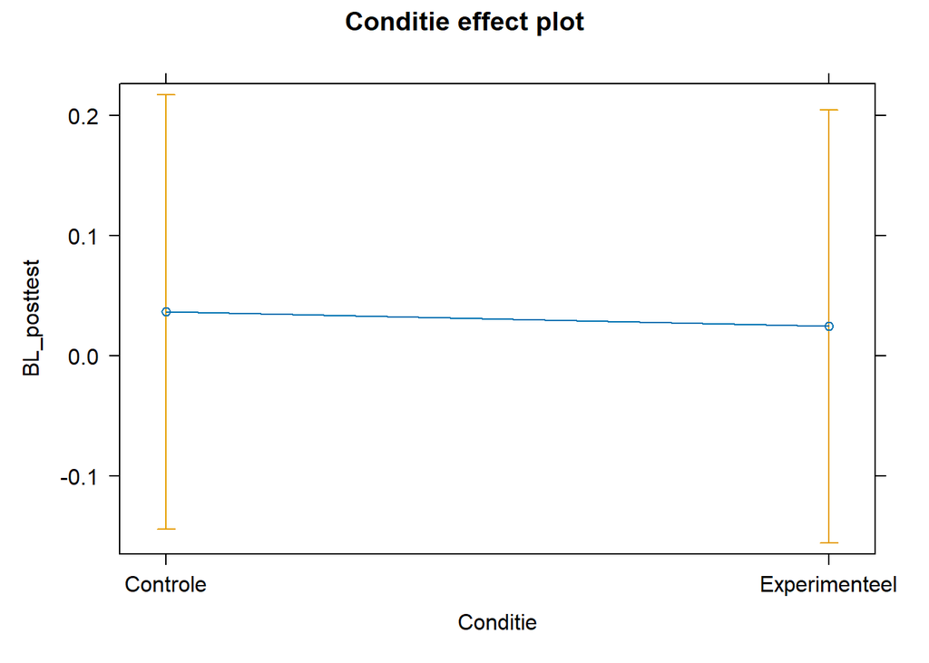

```r
install.packages('effects') # eenmalig
library(effects)

plot(effect('Conditie', model.cndt))
```

## 5.3 Een interactie-effect

Bogaert et al. (2025) vermoeden dat het effect van de interventie (`Conditie`) op de posttestscore (`BL_posttest`) verschillend zou kunnen zijn voor leerlingen met dyslexie in vergelijking met leerlingen zonder dyslexie. Daarom beslissen zij om een interactie tussen de variabelen `Conditie` en `Dyslexie` aan het model toe te voegen.

### Specificatie in R

Met een asterisk `*` kan je een interactie-effect toevoegen aan het model. De asterisk zorgt ervoor dat, naast het interactie-effect zelf, de variabelen `Conditie` en `Dyslexie` allebei ook als hoofdeffect in het model worden opgenomen.[^10] Dat is wenselijk.

```r
model.ia <- lmer(formula = BL_posttest ~ BL_pretest + Conditie*Dyslexie  + (1|Klas), data=lezen)
```

In een diagram ziet dit model er zo uit (klik op de afbeelding om te vergroten):

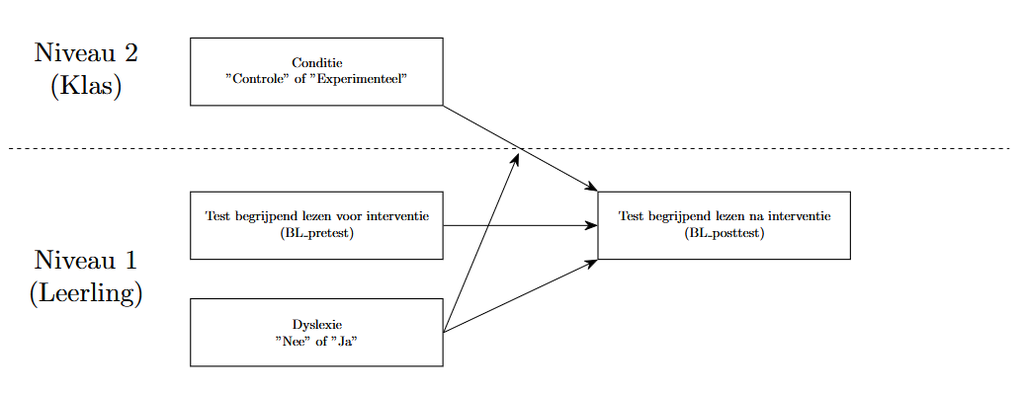

### Parameters schatten

De functie `summary()` geeft ons de belangrijkste informatie over de parameterschattingen.

```r
summary(model.ia)
```

```
Linear mixed model fit by REML. t-tests use Satterthwaite's method ['lmerModLmerTest']
Formula: BL_posttest ~ BL_pretest + Conditie * Dyslexie + (1 | Klas)
   Data: lezen

REML criterion at convergence: 1364.1

Scaled residuals:
    Min      1Q  Median      3Q     Max
-2.3667 -0.6204 -0.1125  0.4693  7.6658

Random effects:
 Groups   Name        Variance Std.Dev.
 Klas     (Intercept) 0.03165  0.1779
 Residual             1.37429  1.1723
Number of obs: 428, groups:  Klas, 27

Fixed effects:
                                  Estimate Std. Error        df t value Pr(>|t|)
(Intercept)                        0.04952    0.09569  22.62317   0.517    0.610
BL_pretest                         0.51244    0.04457 373.36755  11.497   <2e-16 ***
ConditieExperimenteel             -0.01355    0.13571  23.79687  -0.100    0.921
DyslexieJa                        -0.29394    0.38402 422.60242  -0.765    0.444
ConditieExperimenteel:DyslexieJa   0.27432    0.57598 422.60653   0.476    0.634
---
Signif. codes:  0 '***' 0.001 '**' 0.01 '*' 0.05 '.' 0.1 ' ' 1

Correlation of Fixed Effects:
            (Intr) BL_prt CndtEx DyslxJ
BL_pretest  -0.008
CndtExprmnt -0.705 -0.016
DyslexieJa  -0.189  0.017  0.133
CndtExpr:DJ  0.126 -0.061 -0.170 -0.668
```

Omdat zowel `Conditie` als `Dyslexie` slechts 2 waarden kunnen aannemen, is er 1 parameter die codeert voor het interactie-effect. De schatting van deze parameter vinden we onder `Fixed effects`, naast `ConditieExperimenteel:DyslexieJa`.

De interpretatie van de parameter is dezelfde als bij een interactie-effect in een klassiek lineair regressiemodel. Het is het verschil in het effect van de ene variabele in de interactie op de uitkomst, wanneer de andere variabele in de interactie met 1 eenheid toeneemt en wanneer alle andere predictoren constant blijven.

In dit geval schatten we dat het effect van de interventie op `BL_posttest` gemiddeld over alle leerlingen van alle klassen heen, toeneemt met 0.27432 wanneer de dummyvariabele die codeert voor `Dyslexie` met 1 eenheid toeneemt, terwijl `BL_pretest` en `Klas` gelijk blijven. Wanneer de dummy voor `Dyslexie` toeneemt met 1 eenheid betekent dit dat `Dyslexie` de waarde `Ja` heeft in plaats van `Nee`.[^11]

Technisch gezien kan de schatting even goed geïnterpreteerd worden in de andere richting, dus als het verschil in het effect van `Dyslexie` op `BL_posttest` wanneer `Conditie` met 1 eenheid toeneemt. Gegeven de hypothese van de onderzoekers in dit voorbeeld is dat echter niet de relevante interpretatie.

Het is een goed idee om naast puntschattingen ook betrouwbaarheidsintervallen voor de parameters te rapporteren. Dat kan met de functie `confint()`.

```r
confint(model.ia)
```

```
Computing profile confidence intervals ...
```

```
                                      2.5 %    97.5 %
.sig01                            0.0000000 0.3331489
.sigma                            1.0920458 1.2542892
(Intercept)                      -0.1379511 0.2344323
BL_pretest                        0.4251270 0.6083951
ConditieExperimenteel            -0.2755231 0.2525781
DyslexieJa                       -1.0442005 0.4552143
ConditieExperimenteel:DyslexieJa -0.8531328 1.3959948
```

### Toetsen

De relevante nulhypothese en alternatieve hypothese bij het toetsen van een interactie-effect zijn de volgende.

- De nulhypothese stelt dat de populatieparameter $\beta_{Conditie \times Dyslexie}$ gelijk is aan 0. In dat geval is er geen interactie-effect tussen `Conditie` en `Dyslexie`.
- De alternatieve hypothese stelt dat de populatieparameter $\beta_{Conditie \times Dyslexie}$ verschillend is van 0. In dat geval is er wel een interactie-effect tussen `Conditie` en `Dyslexie`.

In dit specifieke geval zouden we de toets van het interactie-effect kunnen uitvoeren op basis van de output van `summary()`.[^12] Omdat dit in veel situaties niet mogelijk is, zullen we hier focussen op een algemeen toepasbare werkwijze:

1. overgaan tot effectcodering van alle categorische predictoren
2. een modelvergelijking uitvoeren met de functie `Anova()` uit het package `car`
3. het argument `type=3` meegeven aan `Anova()`

Meer uitleg over effectcodering en type III toetsen kan je vinden [in deze syllabus](https://statlas.ugent.be/cursussen/MetPsy_cursus20-21_lineaire_regr.pdf#page=64) vanaf sectie 5.3. De uitleg gebeurt in de context van klassieke lineaire regressie (dus niet multilevel modellen) maar de principes zijn identiek.

Voor de eerste stap moeten we het model opnieuw fitten, waarbij we een extra argument `contrasts` meegeven.

```r
model.ia.effect <- lmer(formula = BL_posttest ~ BL_pretest + Conditie*Dyslexie + (1|Klas),
                        data=lezen,
                        contrasts=list(Conditie=contr.sum, Dyslexie=contr.sum))
```

Vervolgens voeren we een modelvergelijking uit waarbij we het model met het interactie-effect vergelijken met het model zonder. We kiezen steeds voor `type=3`.

```r
library(car)
Anova(model.ia.effect, type=3)
```

```
Analysis of Deviance Table (Type III Wald chisquare tests)

Response: BL_posttest
                     Chisq Df Pr(>Chisq)
(Intercept)         0.0578  1     0.8099
BL_pretest        132.1697  1     <2e-16 ***
Conditie            0.1735  1     0.6770
Dyslexie            0.2971  1     0.5857
Conditie:Dyslexie   0.2268  1     0.6339
---
Signif. codes:  0 '***' 0.001 '**' 0.01 '*' 0.05 '.' 0.1 ' ' 1
```

De p-waarde is ongeveer gelijk aan 0.634. Dit is groter dan 0.05 waardoor we de nulhypothese niet kunnen verwerpen op het 5% significantieniveau.

### Visualisatie

Het interactie-effect tussen `Conditie` en `Dyslexie` kan eenvoudig gevisualiseerd worden met het package `effects`. Je geeft `Conditie*Dyslexie` en het model `model.ia` aan de functie `effect()` en geeft dit op zijn beurt aan de functie `plot()`.

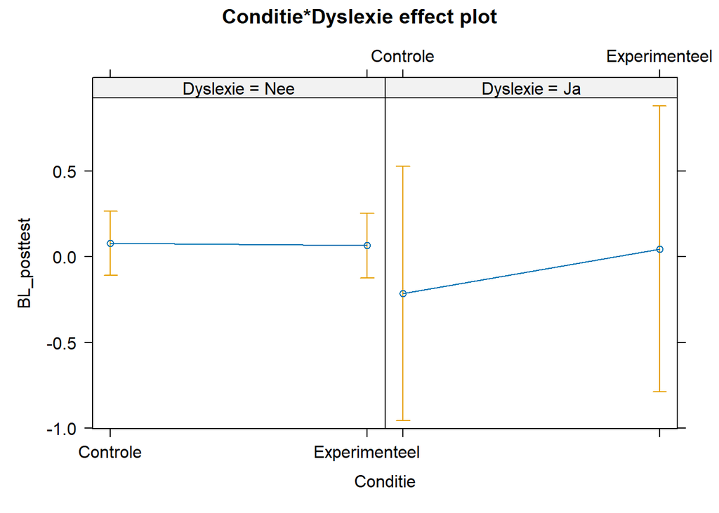

```r
install.packages('effects') # eenmalig
library(effects)

plot(effect('Conditie*Dyslexie', model.ia))
```

Omdat `Conditie*Dyslexie` een interactie-effect voorstelt krijgen we meerdere plots terug. We zien in de output een plot van het effect van `Conditie` op `BL_posttest` wanneer `Dyslexie` de waarde `Ja` aanneemt en een plot van het effect wanneer `Dyslexie` de waarde `Nee` aanneemt. In lijn met de output van `summary(model.ia)` stellen we vast dat het effect van `Conditie` iets groter lijkt te zijn bij de leerlingen die `Dyslexie` hebben (al werd er geen statistisch significant verschil tussen de effecten vastgesteld).

# 6 Varianten en uitbreidingen

Het voorbeeld op deze pagina reikt handvaten aan om zelf multilevel modellen te fitten. Er zijn echter veel concrete situaties denkbaar waarin je de hier gedemonstreerde modellen en bijhorende code zal moeten aanpassen zodat ze jouw concrete onderzoeksvraag kan helpen beantwoorden.

Opties om de hierboven gedemonstreerde technieken toepasbaar te maken op jouw specifieke casus zijn onder meer de volgende.

- **Meer predictoren.** Er is geen harde grens aan het aantal predictoren in een multilevel model. Het is dus mogelijk om (nog) meer predictoren toe te voegen aan het model. Het kan daarbij gaan om hoofdeffecten of interactie-effecten.
- **Meer niveaus.** In het voorbeeld tot hiertoe waren de data geclusterd op een hoger niveau (niveau 2, i.c. het klasniveau). Het is ook mogelijk dat data nog verder geclusterd zijn op een nog hoger, derde niveau.[^13] De klassen maken op hun beurt deel uit van scholen. Als onderzoeker kan je vermoeden dat de testscores (`BL_posttest`) binnen scholen ook wat meer op elkaar lijken in vergelijking met alle leerlingen over alle scholen heen.
- **Random slopes.** In de demonstraties op deze pagina kon het intercept variëren per klas (of algemener geformuleerd, per cluster). In andere multilevel modellen is het ook mogelijk dat de grootte van een effect varieert per cluster. We spreken dan van een “random slope model”. Dergelijke modellen worden gefit wanneer niet voldaan is aan de assumpties van het random intercept model en/of wanneer er theoretische redenen zijn om te denken dat een effect verschillend is per cluster.

  In random slope modellen hebben onderzoekers soms bovendien de bedoeling om de variabiliteit in de slopes tussen klassen te verklaren aan de hand van predictoren. Dan probeert men dus te verklaren waarom de slope in sommige clusters groter of kleiner is dan in andere clusters.

# 7 Referenties

Bogaert R., Merchie E., Van Ammel K. & Van Keer H. (2025). The impact of a tier 1 intervention on fifth and sixth graders’ lezen comprehension, lezen strategy use, and lezen motivation. *Learning Disability Quarterly 48* (2), 102-115. https://doi.org/10.1177/07319487221145691

Chen D. & Chen J.K. (2021). Statistical regression modeling with R. Longitudinal and multi-level modeling. Springer. https://doi.org/10.1007/978-3-030-67583-7

Hox, J. (2010). *Multilevel analysis: techniques and applications.* 2nd ed. New York: Routledge.

Snijders T.A.B. & Bosker R.J. (2012). *Multilevel analysis. An introduction to basic and advanced multilevel modeling.* 2nd ed. London: Sage.

# 8 Voetnoten

[^1]: Aangezien de interventie zelf op klasniveau gebeurt behoren alle leerlingen van dezelfde klas onvermijdelijk tot dezelfde conditie.
[^2]: Leerlingen in de controlegroep legden ook twee testen af, net als leerlingen in de experimentele groep.
[^3]: In klassieke lineaire regressie maken we de assumptie van onafhankelijke observaties. Wanneer de data geclusterd zijn is deze assumptie geschonden.
[^4]: In sommige situaties is dat niet erg. Denk bijvoorbeeld aan PISA-studies, waar het niet altijd noodzakelijk is om te veralgemenen naar andere landen dan degene die opgenomen zijn.
[^5]: De reden daarvoor is dat enkele functies in de beide packages dezelfde naam hebben. De functie van het laatst ingeladen package overschrijft de functie uit het voorgaande package, waardoor die laatste niet meer beschikbaar is. Hier gaat het om de functie `lmer()`.
[^6]: De ICC kan ook geïnterpreteerd worden als de correlatie van waarnemingen binnen de clusters. Waarom het begrip “correlatie” juist van toepassing is wordt uitgelegd in Chen & Chen (2021, p.31-32).
[^7]: De visualisatie op deze pagina is gebouwd met het package `ggplot2`.
[^8]: Het is perfect mogelijk om dit effect ook te laten variëren per klas (of algemener, op niveau 2). In dat geval spreken we van een random slope per klas.
[^9]: In dit specifieke geval kan het resultaat van deze toets worden afgelezen uit de output van `summary()` omdat er slechts 1 parameter is die codeert voor dit effect. Dit zal niet kunnen wanneer de categorische predictor meer dan 2 mogelijke waarden kan aannemen en er dus meer dan 1 parameter codeert voor het effect van die predictor. Bovendien is er in dit model geen interactie-effect aanwezig. Het toetsen van hoofdeffecten in modellen met een interactie-effect vereist extra aandacht en voorzichtigheid.
[^10]: Een equivalente manier om een interactie te coderen is met een `:` tussen `Conditie` en `Dyslexie` en daarnaast expliciet `Conditie` en `Dyslexie` als hoofdeffect toevoegen met `+`.
[^11]: Wanneer categorische variabelen in een model aanwezig zijn, is het altijd belangrijk om op de hoogte te zijn van de details van de codering, en in het bijzonder van het gekozen referentieniveau.
[^12]: In dit specifieke geval kan het resultaat van deze toets worden afgelezen uit de output van `summary()` omdat er slechts 1 parameter is die codeert voor dit effect. Dit zal niet kunnen wanneer de categorische predictoren in het interactie-effect meer dan 2 mogelijke waarden kunnen aannemen en er dus meer dan 1 parameter codeert voor het interactie-effect.
[^13]: Of zelfs op een vierde, vijfde,… niveau.